# OpenAI GPT-4 ChatGPT LangChain 人口知能プログラミング実践入門

#### 編集テキスト生成

モデルエンジンは「text-davinci-edit-001」に変わる

テキスト編集の場合、「prompt」は「input」と「instruction」に変えて指定する

前後のプロンプト（入力文章）を指定

input: 入力テキスト（編集したいテキスト文）

instruction:編集指示

例：

```
input = "今日はとても楽かった。"
instruction = "誤字脱字を修正してください。"
```

#### openai.Edit.create( )の作成パラメーターの説明

パラメーターの解説:

1. 編集パラメーターを指定

   ```
    openai.Edit.create(
   ```

2. 使用するGPT-3エンジンを指定

   ```
    model="text-davinci-edit-001",
   ```

3.入力や編集パラメーターを定義

```
    input=input,

　　instruction=instruction,
```

4. 出力の多様性を制御するための温度パラメーターを指定

※デフォルト: 1、0～2範囲内に設定※

```
    temperature=0)
```

```python
# テキスト編集プロンプトの準備
input = "今日はとても楽かった。"
instruction = "誤字脱字を修正してください。"
```

```python
import openai

# 編集の実行
response = openai.Edit.create(
    model="text-davinci-edit-001",
    input=input,
    instruction=instruction,
    temperature=0
)
print(response["choices"][0]["text"])

#表示結果の例↓
# 今日はとても楽しかった。
```

```
今日はとても楽しかった。
```

### 画像生成について

公式サイト

https://platform.openai.com/docs/guides/images

画像生成には3つの機能がある:

- テキストからの画像生成
- 画像とテキストからの画像編集
- 画像からのバリエーション生成

利用料金:

OpenAI Playgroundの利用料金と同じである

常に実行するコードセットを用意し、利用パラメーターも料金プラン※範囲内に入るように設定しておく必要がある

設定パラメーター料金プランはOpenAI Playgroundの利用料金・トークン数についてをご参照ください

尚）各自「生成に要するパラメーター」は決まっているので各自のパラメーター基準表に従ってください

```
openai.Image.create( ):画像生成パラメーター

openai.Image.create_edit( ):画像編集パラメーター

openai.Image.create_variation( ):バリエーション画像パラメーター

openai.Embedding.create( ):埋め込み画像パラメーター
```

尚）各自生成出力に要する「レスポンスパラメーター」は決まっているので各自のパラメーター基準表に従ってください

```
openai.Image.create( ):画像生成のレスポンスパラメーター

openai.Image.create_edit( ):画像編集のレスポンスパラメーター

openai.Image.create_variation( ):バリエーション画像のレスポンスパラメーター

openai.Embedding.create( ):埋め込み画像のレスポンスパラメーター
```

#### openai.Image.create( )のパラメーター

| パラメーター | 説明 |
| --- | --- |
| prompt | 画像内容テキストは1000文字まで |
| n | 生成画像の枚数は10枚まで、デフォルト:1 |
| size | 生成画像のサイズ256x256/512x512/1024x1024/ デフォルト:1024x1024 |
| response_format | 生成画像の形式(url/b64_json) |
| user | エンドユーザーID |

#### openai.Image.create_edit( )のパラメーター

| パラメーター | 説明 |
| --- | --- |
| image | 編集する画像は4MB未満の正方形写真 (PNG(RGBA)) |
| mask | 編集エリアのマスク画像は4MB未満の正方形写真 (PNG(RGBA)) |
|  | 編集領域に透明色を指定 |
| prompt | 画像内容テキストは1000文字まで |
| n | 生成画像の枚数は10枚まで、デフォルト:1 |
| size | 生成画像のサイズ256x256/512x512/1024x1024/ デフォルト:1024x1024 |
| response_format | 生成画像の形式(url/b64_json) |
| user | エンドユーザーID |

前準備:

1. Ｃｏｌａｂノートブックを開く
2. openaiパッケージをインストールする

   ```
    !pip install openai
   ```

3. 環境変数の準備をする(有料版、無料版の場合は不要）

   ```
    import os
    os.environ["OPENAI_API_KEY"] = "<OpenAI_APIのAPIキー>"
   ```

入力（プロンプト）の準備:

4. 予めに「prompt = 画像内容を入力」を以下のように書いて準備しておく必要がある

   ```
    prompt = "A colorful trees with fruits over the mountains."
   ```

画像生成に要するパラメーター例:

5. テキストからの画像生成の実行する画像内容はprompt通りと指定
6. 生成枚数やサイズを指定

   ```
    import openai

    response = openai.Image.create(
        prompt=prompt,
        n=1,
        size="512x512"
    )
   ```

7. 画像のurl出力を指定

   ```
    image_url = response["data"][0]["url"]
   ```

8. 画像urlの表示命令

   ```
    print(image_url)

    print(response)
   ```

9. 画像・urlが出力される

クリックすると生成画像が表示される

```
    https://oaidalleapiprodscus.blob.core.windows.net/private/org-NjF1gp1qnlpNzEmqp6EJAW3q/user-c3zZjM7KFAtCNeD4qSCzR7mv/img-PMq7flnnKFR8s9OX1lU8hFUB.png?st=2023-08-09T00%3A09%3A04Z&se=2023-08-09T02%3A09%3A04Z&sp=r&sv=2021-08-06&sr=b&rscd=inline&rsct=image/png&skoid=6aaadede-4fb3-4698-a8f6-684d7786b067&sktid=a48cca56-e6da-484e-a814-9c849652bcb3&skt=2023-08-08T18%3A42%3A13Z&ske=2023-08-09T18%3A42%3A13Z&sks=b&skv=2021-08-06&sig=WcQVOcNTFplsXAPadvLRxvMsXvaUpQMo6TxO4sAhLtU%3D
```

```python
#例1: 画像生成プロンプトの準備
import openai

openai.api_key = "your_API_key"

# Example prompt
prompt = "A colorful trees with fruits over the mountains."

# Generate the image
response = openai.Image.create(
    prompt=prompt,
    n=1,
    size="512x512"
)
image_url = response["data"][0]["url"]

# Open the image in a web browser
print(image_url)
```

```
https://oaidalleapiprodscus.blob.core.windows.net/private/org-NjF1gp1qnlpNzEmqp6EJAW3q/user-c3zZjM7KFAtCNeD4qSCzR7mv/img-NFo5D97C8cwYubeTbsmil1Eo.png?st=2023-08-28T02%3A54%3A17Z&se=2023-08-28T04%3A54%3A17Z&sp=r&sv=2021-08-06&sr=b&rscd=inline&rsct=image/png&skoid=6aaadede-4fb3-4698-a8f6-684d7786b067&…
```

```python
from IPython.display import Image

# Display the image using its URL
Image(url=image_url)

#図4.5 出所: ＯｐｅｎＡＩ生成画像 |A colorful trees with fruits over the mountains.
```

[output not shown]

```python
#例2: 画像生成プロンプトの準備（無料版）
prompt = "cat dancing on car"
```

```python
import openai

# テキストからの画像生成の実行
response = openai.Image.create(
    prompt=prompt,
    n=1,
    size="512x512"
)
image_url = response["data"][0]["url"]
print(image_url)
```

```
https://oaidalleapiprodscus.blob.core.windows.net/private/org-NjF1gp1qnlpNzEmqp6EJAW3q/user-c3zZjM7KFAtCNeD4qSCzR7mv/img-wQMHlbwhs5zyuh8dHYv3R2aK.png?st=2023-08-28T02%3A55%3A44Z&se=2023-08-28T04%3A55%3A44Z&sp=r&sv=2021-08-06&sr=b&rscd=inline&rsct=image/png&skoid=6aaadede-4fb3-4698-a8f6-684d7786b067&…
```

```python
from IPython.display import Image

# Display the image using its URL
Image(url=image_url)

#図4.6 出所: ＯｐｅｎＡＩ生成画像 |cat dancing on car
```

[figure not shown]

#### 画像とテキストからの画像編集

1. 入力（プロンプト）の準備:

予めに「prompt = 画像内容を入力」を以下のように書いて準備しておく必要がある

```
    prompt = "A colorful trees with fruits over the mountains."
```

2. 編集写真の指示

対象の画像の定義「image = " .png", "rb"」と編集エリアをマスクして定義「mask = " .png", "rb"」をする

```
image = open("image.png", "rb")
mask = open("mask.png", "rb")
```

3. 画像ファイルの準備について

[figure not shown]

図4.7 出所: OpenAI GPT-4 ChatGPT LangChain 人口知能プログラミング実践入門 |画像編集用写真 |画像編集用マスク写真

編集用写真の準備について：

```
お好みの画像を使って編集写真とマスク写真を作成

「第２章のインペインティング機能ご参照」
```

またはインペインティングせずにダウンロードすることも可能

```
https://www.borndigital.co.jp/book/

ダウンロードファイル名

image.png

mask.png
```

または本画面にでている写真からコピーが可能

```
3-1. 写真（図4.7)（図4.8)を右クリック

3-2. 名前つけて画面を保存(image.png)

3-3.この写真を各自のPCに保存

3-4.Colab ファイルの左のフォルダを押す

3-5.↑マークを押す

3-6. 編集写真 image.pngファイルをアップロード

3-7. 以下のコードでダウンロード
```

```python
#ダウンロード前にインストールする
!pip install Pillow
!pip install --upgrade Pillow
```

[output not shown]

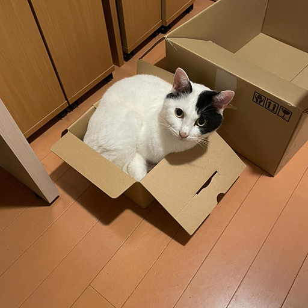

```python
#図4.7 元の画像をアップロード
#Colab ファイルの左のフォルダを押すー＞↑マークを押すー＞編集.pngファイルをアップロードー＞以下のコードでダウンロード
from PIL import Image
from IPython.display import display

# 画像ファイルのパス
image_path = "/content/image.png"  # 画像ファイルの実際のパスを指定してください

# 画像を開く
image = Image.open(image_path)

# 画像の表示
display(image)
```

```python
# 画像の情報を表示
print("Image format:", image.format)  # 画像フォーマット（JPEG、PNGなど）
print("Image size:", image.size)      # 画像サイズ（幅 x 高さ）
print("Image mode:", image.mode)      # 画像モード（RGB、Lなど）
```

```
Image format: PNG
Image size: (512, 512)
Image mode: RGB
```

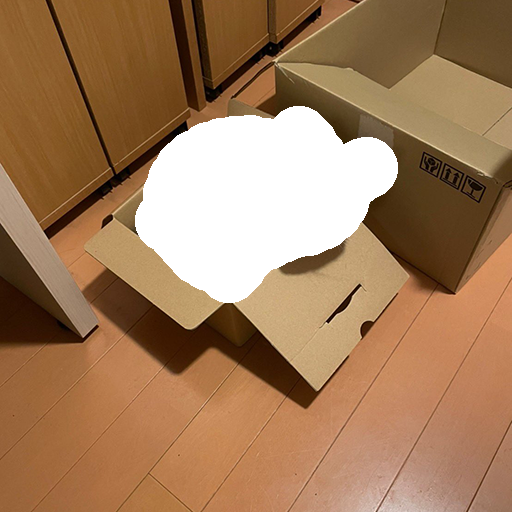

```python
#図4.8 編集マスク画像をアップロード
#Colab ファイルの左のフォルダを押すー＞↑マークを押すー＞編集.pngファイルをアップロードー＞以下のコードでダウンロード

from PIL import Image
from IPython.display import display

# 画像ファイルのパス
image_path = "/content/mask.png"  # 画像ファイルの実際のパスを指定してください

# 画像を開く
mask = Image.open(image_path)

# 画像の表示
display(mask)
```

画像生成に要するパラメーター例:

4. テキストからの画像生成の実行する画像内容はprompt通りと指定

生成枚数やサイズを指定

```
import openai

response = openai.Image.create(
    prompt=prompt,
```

5. 編集用コーディングも追加、他のコーディングは変わらない

   ```
    image=image,
    mask=mask,
    n=1,
    size="512x512"
   ```

   )
6. 画像のurl出力を指定

   ```
    image_url = response["data"][0]["url"]
   ```

7. 画像urlの表示命令

   ```
    print(image_url)

    print(response)
   ```

8. 画像・urlが出力される

クリックすると生成画像が表示される

```python
# 画像とマスクの準備 (画像とマスクをカレントフォルダに置いておきます)
image = open("image.png", "rb")
mask = open("mask.png", "rb")
```

```python
import openai

# 画像とテキストからの画像編集の実行
response = openai.Image.create_edit(
  image=image,
  mask=mask,
  prompt="a few beautiful apples in cardboard box",
  n=1,
  size="512x512"
)
image_url = response["data"][0]["url"]
print(image_url)
```

```
https://oaidalleapiprodscus.blob.core.windows.net/private/org-NjF1gp1qnlpNzEmqp6EJAW3q/user-c3zZjM7KFAtCNeD4qSCzR7mv/img-BTXw0Ma6f5VlBkcgxbMgmX8h.png?st=2023-08-28T02%3A50%3A06Z&se=2023-08-28T04%3A50%3A06Z&sp=r&sv=2021-08-06&sr=b&rscd=inline&rsct=image/png&skoid=6aaadede-4fb3-4698-a8f6-684d7786b067&…
```

```python
from IPython.display import Image

# Display the image using its URL
Image(url=image_url)

#図4.9 出所: OpenAI GPT-4 ChatGPT LangChain 人口知能プログラミング実践入門 |編集後の生成画像の例
```

[figure not shown]

#### 画像からのバリエーション生成

画像生成と同様に設定するが、生成の指定パラメーターはバリエーション機能の指示にするため「response = openai.Image.create_variation(）」に変わっただけで他はやることが一緒なので「画像生成の例をご参照ください」

#### openai.Image.create_variation( )のパラメーター

| パラメーター | 説明 |
| --- | --- |
| image | 編集する画像は4MB未満の正方形写真 (PNG(RGBA)) |
| n | 生成画像の枚数は10枚まで、デフォルト:1 |
| size | 生成画像のサイズ256x256/512x512/1024x1024/ デフォルト:1024x1024 |
| response_format | 生成画像の形式(url/b64_json) |
| user | エンドユーザーID |

```python
# 画像とマスクの準備
image = open("image.png", "rb")
```

```python
import openai

# 画像からのバリエーション生成
response = openai.Image.create_variation(
  image=image,
  n=1,
  size="512x512"
)
image_url = response["data"][0]["url"]
print(image_url)
```

```
https://oaidalleapiprodscus.blob.core.windows.net/private/org-NjF1gp1qnlpNzEmqp6EJAW3q/user-c3zZjM7KFAtCNeD4qSCzR7mv/img-mn8OqV83TrkzYeKmrmp1S1Yl.png?st=2023-08-28T02%3A50%3A25Z&se=2023-08-28T04%3A50%3A25Z&sp=r&sv=2021-08-06&sr=b&rscd=inline&rsct=image/png&skoid=6aaadede-4fb3-4698-a8f6-684d7786b067&…
```

```python
from IPython.display import Image

# Display the image using its URL
Image(url=image_url)

# 図4.10 出所: OpenAI GPT-4 ChatGPT LangChain 人口知能プログラミング実践入門 |バリエーション機能生成画像の例
```

[figure not shown]

### 埋め込みデータの生成について

公式サイト

Embeddings-OpenAI API

https://platform.openai.com/docs/guides/embeddings/

クラスタリングやレコメンドなどのデータ分析に活用する埋め込み（Embedding）生成:

テキストをコンピュータが処理しやすい形式で表現するための手法である

テキストを「ベクトル表現」（浮動小数配列）に変換する

ベクトル表現の目的:

- 検索：クリエ文字列との関連性によって結果をランクつけ
- クラスタリング：テキストの関連性によってグループ化
- レコメンド：テキストの関連性によってコメント
- 異常検出：類似度がほとんどない外れ値を検出
- 多様性測定：類似度分布を分析
- 分類：テキストが最も類似したラベルによって分類

利用料金:

「テキスト生成」「画像生成」と同様に「埋め込み生成」も「OpenAI API」の利用料金nに参考できる

Embeddingモデル:

text-embedding-ada-002

#### openai.Embedding.create( )のパラメーター

| パラメーター | 説明 |
| --- | --- |
| model | モデルID |
| input | 埋め込み生成する文字列、または文字列配列 |
| user | エンドユーザーID |

前準備:

テキスト生成と同じい前準備をする

1. パッケージのインストール

   ```
    !pip install openai
   ```

2. 環境変数の準備

   ```
    import os
    os.environ["OPENAI_API_KEY"] = "Set your OpenAI API key"
   ```

3. 埋め込みに変換するテキストの準備

   ```
    text = "これはテストです。"
   ```

埋め込み生成の例:

テキストを埋め込みに変換する

4.パラメーターを定義

```
response = openai.Embedding.create(
```

5.変換元の定義

```
    input=text,
```

6.モデルを定義

```
    model="text-embedding-ada-002"
)
```

7.表示命令

```
print(len(response["data"][0]["embedding"]))
print(response["data"][0]["embedding"])
```

8.表示結果

「テスト」という文字をコンピュータが処理しやすい形式で「ベクトル表現」または（浮動小数配列）に変換されて以下のように結果が表示される

[-0.0018796126823872328, -0.011050041764974594, -0.00236902735196054, -0.01619458757340908, -0.007733077742159367, 0.005056743510067463,...

```python
# パッケージのインストール
!pip install openai
```

```python
# 環境変数の準備
import os
os.environ["OPENAI_API_KEY"] = "Set your OpenAI API key"
```

```python
# 埋め込みに変換するテキストの準備
text = "これはテストです。"
```

```python
import openai

# テキストを埋め込みに変換
response = openai.Embedding.create(
    input=text,
    model="text-embedding-ada-002"
)

# 確認
print(len(response["data"][0]["embedding"]))
print(response["data"][0]["embedding"])

#表示結果の例↓
# 1536次元の「ベクトル表現」結果が得られる
# 1536
# [-0.0018796126823872328, -0.011050041764974594, -0.00236902735196054, -0.01619458757340908, -0.007733077742159367, 0.005056743510067463,...
```

```
1536
[-0.0018796126823872328, -0.011050041764974594, -0.00236902735196054, -0.01619458757340908, -0.007733077742159367, 0.005056743510067463, -0.021059466525912285, -0.01351500116288662, 0.00506324740126729, -0.024662600830197334, 0.003856783267110586, 0.015179986134171486, -0.0017869328148663044, -0.030…
```

### 近傍探索について

公式サイト

facebookresearch/faiss

https://github.com/facebookresearch/faiss

埋め込みの主な使用例は近傍探索である

入力テキストの意味の近いものを対象のテキストから探すタスクのことが近傍探索である

本章ではFacebookが開発したオーポンソースのベクトルデータベース Faiss を使って近傍探索を実行する

モデル: text-embedding-ada-002

前準備:

Faiss の GPU版を使うため、GPUを有効化する

ノートブックー>メニューー>編集ー>ノートブックの設定ー>GPU

[figure not shown]

図4.11 出所: Skill Up AIより. 公式Webサイト |Colabの環境をGPUに設定するため、「ハードウェア アクセラレータ」を「GPU」に変更して「保存」をする画面

#### 近傍探索アルゴリズムのIndex

| インデックス | 説明 |
| --- | --- |
| IndexFlatL2(L2ノルム | ユークリッド距離を使用してベクトルの距離を計算する |
|  | 基本的なインデックス |
| IndexFlatIP(コサイン類似度） | 内積を使用してベクトル間の類似度を計算する |
| IndexIVFFlat(高速化アルゴリズム) | 高次元ベクトルをクラスタリングすることによってベクトルの検索を高速化する |

index.search()の引数

| 引数 | 説明 |
| --- | --- |
| in_embeds | 検索したいベクトルのNumpy配列 |
| k | 返される最近傍ベクトルの数 |

index.search()の戻り値

| 戻り値 | 説明 |
| --- | --- |
| D | 最も近いベクトルとの距離 |
| I | 最も近いベクトルとのインデックス |

テキスト生成と同じい前準備をする:

1. Faissパッケージのインストール

   ```
    !pip install faiss-gpu
   ```

2. 環境変数の準備

   ```
    import openai
    import numpy as np
   ```

3. 入力テキストの準備

   ```
    in_text = "今日は雨振らなくてよかった"
   ```

4.パラメーターを定義

```
response = openai.Embedding.create(
```

5.変換元の定義

```
    input=in_text,
```

6.モデルを定義

```
        model="text-embedding-ada-002"
    )
```

7.入力テキストの埋め込み生成

in_embeds = [record["embedding"] for record in response["data"]] in_embeds = np.array(in_embeds).astype("float32")

8.近傍探索出力用対象テキストの準備

```
    target_texts = [
        "好きな食べ物は何ですか?",
        "どこにお住まいですか?",
        "朝の電車は混みますね",
        "今日は良いお天気ですね",
        "最近景気悪いですね"]
```

9.出力テキスト用パラメーター、変換元、モデルを定義

```
response = openai.Embedding.create(
    input=target_texts,
    model="text-embedding-ada-002"
)
```

10.対象テキストの埋め込み生成:

target_embeds = [record["embedding"] for record in response["data"]] target_embeds = np.array(target_embeds).astype("float32")

11.Faissのインデックス生成

```
    import faiss
    index = faiss.IndexFlatL2(1536)
```

12.対象テキストをインデックスに追加

```
    index.add(target_embeds)
```

13.近傍探索の実行

```
    D, I = index.search(in_embeds, 1)
```

14.表示命令

```
    print(D)
    print(I)
    print(target_texts[I[0][0]])
```

8.表示結果

入力テキストの意味の近いものを対象のテキストから探し、近傍探索した結果が表示される

[[0.17803922]]

[[3]]

今日は良いお天気ですね

```python
# Faissパッケージのインストール
!pip install faiss-gpu
```

```
     ━━━━━━━━━━━━━━━━━━━━━━━━━━━━━━━━━━━━━━━━ 85.5/85.5 MB 8.0 MB/s eta 0:00:00
```

```python
import openai
import numpy as np

# 入力テキストの埋め込み生成
in_text = "今日は雨振らなくてよかった"
response = openai.Embedding.create(
    input=in_text,
    model="text-embedding-ada-002"
)
in_embeds = [record["embedding"] for record in response["data"]]
in_embeds = np.array(in_embeds).astype("float32")

# 対象テキストの埋め込み生成
target_texts = [
    "好きな食べ物は何ですか?",
    "どこにお住まいですか?",
    "朝の電車は混みますね",
    "今日は良いお天気ですね",
    "最近景気悪いですね"]
response = openai.Embedding.create(
    input=target_texts,
    model="text-embedding-ada-002"
)
target_embeds = [record["embedding"] for record in response["data"]]
target_embeds = np.array(target_embeds).astype("float32")
```

```python
import faiss

# Faissのインデックス生成
index = faiss.IndexFlatL2(1536)
```

```python
# 対象テキストをインデックスに追加
index.add(target_embeds)
```

```python
# 近傍探索の実行
D, I = index.search(in_embeds, 1)

# 確認
print(D)
print(I)
print(target_texts[I[0][0]])
```

```
[[0.17803922]]
[[3]]
今日は良いお天気ですね
```

```python
!pip install matplotlib
```

### ファインチューニング

ファインチューニングとは、既に学習済みの言語モデルを、特定のタスクに最適化することである

公式サイト

Fine-tuning -OpenAI API

https://platform.openai.com/docs/guides/fine-tuning

ファインチューニングは事前学習済みモデルをベースに、個別タスクに合わせて行う追加学習である

利点としてはプロンプトで例を提供する必要がなくなり、結果としてトークン数が節約され、低遅延のリクエストが可能になる

ファインチューニング可能なモデル

- Davinci
- Curie
- Babbage
- Ada

#### Fine-tuning modelsの料金（学習）

| モデル | 料金（ドル） | 円（１ドル=130円レートで計算） |
| --- | --- | --- |
| Davinci | 0.0300ドル/1Kトークン | 3.900 |
| Curie | 0.0030ドル/1Kトークン | 0.390 |
| Bubbage | 0.0006ドル/1Kトークン | 0.078 |
| Ada | 0.0004ドル/1Kトークン | 0.052 |

#### Fine-tuning modelsの料金（使用）

| モデル | 料金（ドル） | 円（１ドル=130円レートで計算） |
| --- | --- | --- |
| Davinci | 0.1200ドル/1Kトークン | 15.600 |
| Curie | 0.0120ドル/1Kトークン | 1.560 |
| Bubbage | 0.0024ドル/1Kトークン | 0.312 |
| Ada | 0.0016ドル/1Kトークン | 0.208 |

前準備:

パッケージのインストール

```
    !pip install openai
    !pip install --upgrade openai
```

環境変数の準備

```
    import os
    os.environ["OPENAI_API_KEY"] = "Set your OpenAI API key"
```

事前にT4:GPUを有効化する

```
    ノートブックー>メニューー>編集ー>ノートブックの設定ー>GPU
```

使われるモデル名を確認

```
    例 モデルID :davinci
```

```python
# パッケージのインストール
!pip install openai
!pip install --upgrade openai
```

```
     ━━━━━━━━━━━━━━━━━━━━━━━━━━━━━━━━━━━━━━━━ 73.6/73.6 kB 1.3 MB/s eta 0:00:00
```

```python
# 環境変数の準備　#Set your OpenAI API key
import os
os.environ["OPENAI_API_KEY"] = "your_API_key"
```

#### 学習データの準備:

https://www.borndigital.co.jp/book/%E3%81%AE%E6%83%85%E5%A0%B1%E3%81%AB%E3%82%88%E3%82%8A

1. 日本語の会話学習済のエクセル・データベース「つくよみちゃん会話AI育成計画.xlsxファイル」を使用してファインチューニングを行う

「つくよみちゃん会話AI育成計画.xlsx」のデータ形式について:

会話生成のテキストデータはプロンプト'prompt'とコンプリーション'completion'というペアで構成されている

```
    names=['prompt','completion'],
```

2. ファイルのダウンロード先

https://tyc.rei-yumesaki.net/material/kaiwa-ai/

3. ダウンロードファイルのファイル名をColabで対応可能なファイルタイプへ変更し、PCに保存

   ```
    tsukuyomi.csv
   ```

4. このファイルをColabのフォルダにアップロード

   ```
    フォルダマークをクリック-> ツールバーの↑を押す -> PCに保存したファイルを選択 -> アップロード完了
   ```

5. 以下のコードでコードセルにデータベースを追加し、データセットの準備が完了

   ```
    import pandas as pd

    df = pd.read_csv(
        './tsukuyomi.csv',
        usecols=[1,2],
        names=['prompt','completion'],
        skiprows=2)
   ```

このコマンドで names=['prompt','completion']データが tsukuyomi.jsonl 形式へ変換される

```
    df.to_json(
        "tsukuyomi.jsonl",
        orient='records',
        lines=True,
        force_ascii=False
    )
```

データを表示してみる

df.head() を追加して'prompt','completion'の内容を確認する

```python
import pandas as pd

# データセットの準備

df = pd.read_csv(
    './tsukuyomi.csv',
    usecols=[1,2],
    names=['prompt','completion'],
    skiprows=2)
df.head()
```

|  | prompt | completion |
| --- | --- | --- |
| 0 | お腹が鳴る | 何か召し上がりますか？ |
| 1 | だるい | それは心配です。私にできることがあれば、何でもお申し付けください。 |
| 2 | 眠れない | 何も心配する必要はありません。私がついています。ずっと、ずっと、一緒です。 |
| 3 | 押すなよ、絶対押すなよ | はい、絶対押しません！ |
| 4 | 見せられないよ | 目をつぶって待っています。 |

.csv -> .jsonl へデータ変換

```python
import pandas as pd

# データセットの準備

df = pd.read_csv(
    './tsukuyomi.csv',
    usecols=[1,2],
    names=['prompt','completion'],
    skiprows=2)
df.to_json(
    "tsukuyomi.jsonl",
    orient='records',
    lines=True,
    force_ascii=False
)
```

6. データセットの検証を行う

-f:検証ファイル

-q: ユーザー入力なしに、全提案を受け入れて自動修正

```
    !openai tools fine_tunes.prepare_data \
        -f tsukuyomi.jsonl \
        -q
```

7. 検証結果の表示例（全文）:

   ```
    Analyzing...

    Based on the analysis we will perform the following actions:
    - [Recommended] Remove 530 duplicate rows [Y/n]: Y
    - [Recommended] Add a suffix separator ` ->` to all prompts [Y/n]: Y
    /usr/local/lib/python3.10/dist-packages/openai/validators.py:226: SettingWithCopyWarning:
    A value is trying to be set on a copy of a slice from a DataFrame.
    Try using .loc[row_indexer,col_indexer] = value instead

    See the caveats in the documentation: https://pandas.pydata.org/pandas-docs/stable/user_guide/indexing.html#returning-a-view-versus-a-copy
      x["prompt"] += suffix
    - [Recommended] Add a suffix ending `\n` to all completions [Y/n]: Y
    /usr/local/lib/python3.10/dist-packages/openai/validators.py:382: SettingWithCopyWarning:
    A value is trying to be set on a copy of a slice from a DataFrame.
    Try using .loc[row_indexer,col_indexer] = value instead

    See the caveats in the documentation: https://pandas.pydata.org/pandas-docs/stable/user_guide/indexing.html#returning-a-view-versus-a-copy
      x["completion"] += suffix
    - [Recommended] Add a whitespace character to the beginning of the completion [Y/n]: Y
    /usr/local/lib/python3.10/dist-packages/openai/validators.py:425: SettingWithCopyWarning:
    A value is trying to be set on a copy of a slice from a DataFrame.
    Try using .loc[row_indexer,col_indexer] = value instead

    See the caveats in the documentation: https://pandas.pydata.org/pandas-docs/stable/user_guide/indexing.html#returning-a-view-versus-a-copy
      x["completion"] = x["completion"].apply(

    Your data will be written to a new JSONL file. Proceed [Y/n]: Y

    Wrote modified file to `tsukuyomi_prepared.jsonl`
    Feel free to take a look!

    Now use that file when fine-tuning:
    > openai api fine_tunes.create -t "tsukuyomi_prepared.jsonl"

    After you’ve fine-tuned a model, remember that your prompt has to end with the indicator string ` ->` for the model to start generating completions, rather than continuing with the prompt. Make sure to include `stop=["\n"]` so that the generated texts ends at the expected place.
    Once your model starts training, it'll approximately take 26.18 minutes to train a `curie` model, and less for `ada` and `babbage`. Queue will approximately take half an hour per job ahead of you.
   ```

8. 検証したデータセットは以下のファイル名でColabフォルダに出力される

このファイルは項6の修正によって会話の文章が改行されたものになる

```
    tsukuyomi_prepared.jsonl
```

```python
# データセットの検証
!openai tools fine_tunes.prepare_data \
    -f tsukuyomi.jsonl \
    -q
```

```
/bin/bash: line 1: openai: command not found
```

#### ファインチューニングの実行

```
!openai api fine_tunes.create \
    -t "tsukuyomi_prepared.jsonl" \
    -m <モデルID>
```

以下のファイルIDが表示される

IDが表示結果の3と4行目に表示される↓

```
=====================================================
Found potentially duplicated files with name 'tsukuyomi_prepared.jsonl', purpose 'fine-tune' and size 71445 bytes
file-8DX4qzZYOLB8oN7rUiPD08Qv
file-AeCPJ6NExDkjWWVBYuVOXtxQ
Enter file ID to reuse an already uploaded file, or an empty string to upload this file anyway:
```

ファイルIDをメモしておいてください

```
file-8DX4qzZYOLB8oN7rUiPD08Qv
file-AeCPJ6NExDkjWWVBYuVOXtxQ
```

後でファイルの再アップロード時にファイルのID入力が求められる

または

ファイルIDの入力が求められるときに空のエンターを押してもOK

ファインチューニングの実行結果の例(全文）：

```
    ======================================================================
    Found potentially duplicated files with name 'tsukuyomi_prepared.jsonl', purpose 'fine-tune' and size 71445 bytes
    file-8DX4qzZYOLB8oN7rUiPD08Qv
    file-AeCPJ6NExDkjWWVBYuVOXtxQ
    Enter file ID to reuse an already uploaded file, or an empty string to upload this file anyway:
    Upload progress: 100% 71.4k/71.4k [00:00<00:00, 81.4Mit/s]
    Uploaded file from tsukuyomi_prepared.jsonl: file-huEnUYUWmlVLkQY1NV4Gke0i
    Created fine-tune: ft-5jZl5NYoXQD3JhJNfnUNPyey
    Streaming events until fine-tuning is complete...

    (Ctrl-C will interrupt the stream, but not cancel the fine-tune)
    [2023-08-09 06:44:31] Created fine-tune: ft-5jZl5NYoXQD3JhJNfnUNPyey

    Stream interrupted (client disconnected).
    To resume the stream, run:

      openai api fine_tunes.follow -i ft-5jZl5NYoXQD3JhJNfnUNPyey
```

```python
# ファインチューニングの実行
!openai api fine_tunes.create -t "tsukuyomi_prepared.jsonl" -m davinci
```

```
Found potentially duplicated files with name 'tsukuyomi_prepared.jsonl', purpose 'fine-tune' and size 71445 bytes
file-huEnUYUWmlVLkQY1NV4Gke0i
file-8DX4qzZYOLB8oN7rUiPD08Qv
file-AeCPJ6NExDkjWWVBYuVOXtxQ
file-urmrjFkx9XWXXfAanFIkMnZf
file-nOMwoKl5ib8C51dM3745BHxH
file-z5FoCU2eM3agGtiROCfLFMXo
file-VNalG599hLl8Yi1sjIr9yQGF
Enter file ID to reuse an already uploaded file, or an empty string to upload this file anyway:
Upload progress: 100% 71.4k/71.4k [00:00<00:00, 78.7Mit/s]
Uploaded file from tsukuyomi_prepared.jsonl: file-1FmxHg6KV2fQiFLqjjA2voz6
Created fine-tune: ft-6Gny0lfEQeuhTaYvPotGBftM
Streaming events until fine-tuning is complete...

(Ctrl-C will interrupt the stream, but not cancel the fine-tune)
[2023-08-10 04:59:55] Created fine-tune: ft-6Gny0lfEQeuhTaYvPotGBftM

Stream interrupted (client disconnected).
To resume the stream, run:

  openai api fine_tunes.follow -i ft-6Gny0lfEQeuhTaYvPotGBftM
```

```python
# ストリーム再開
!openai api fine_tunes.follow -i ft-6Gny0lfEQeuhTaYvPotGBftM
```

```
[2023-08-10 04:59:55] Created fine-tune: ft-6Gny0lfEQeuhTaYvPotGBftM

Stream interrupted (client disconnected).
To resume the stream, run:

  openai api fine_tunes.follow -i ft-6Gny0lfEQeuhTaYvPotGBftM
```

```python
# ファインチューニングのジョブの確認
!openai api fine_tunes.get -i ft-6Gny0lfEQeuhTaYvPotGBftM
```

[output not shown]

```python
# ジョブキャンセル
!openai api fine_tunes.cancel -i ft-6Gny0lfEQeuhTaYvPotGBftM
```

```
{
  "object": "fine-tune",
  "id": "ft-6Gny0lfEQeuhTaYvPotGBftM",
  "hyperparams": {
    "n_epochs": 4,
    "batch_size": null,
    "prompt_loss_weight": 0.01,
    "learning_rate_multiplier": null
  },
  "organization_id": "org-NjF1gp1qnlpNzEmqp6EJAW3q",
  "model": "davinci",
  "training_files": [
    {
      "object": "file",
      "id": "file-1FmxHg6KV2fQiFLqjjA2voz6",
      "purpose": "fine-tune",
      "filename": "tsukuyomi_prepared.jsonl",
      "bytes": 71445,
      "created_at": 1691643595,
      "status": "processed",
      "status_details": null
    }
  ],
  "validation_files": [],
  "result_files": [],
  "created_at": 1691643595,
  "updated_at": 1691643784,
  "status": "cancelled",
  "fine_tuned_model": null,
  "events": [
    {
      "object": "fine-tune-event",
      "level": "info",
      "message": "Created fine-tune: ft-6Gny0lfEQeuhTaYvPotGBftM",
      "created_at": 1691643595
    },
    {
      "object": "fine-tune-event",
      "level": "info",
      "message": "Fine-tune cancelled",
      "created_at": 1691643784
    }
  ]
}
```

#### 推論の実行

```python
import openai

# 推論の実行
prompt="好きな食べ物は何？->"
response = openai.Completion.create(
    model="davinci",
    prompt=prompt,
    max_tokens=100,
    stop="\n")
print(response["choices"][0]["text"])
```

```
かぼちゃ！
```

#### ファインチューニングモデルの一覧取得と削除

```python
# ファインチューニングモデル一覧確認
!openai api fine_tunes.list
```

```
{
  "object": "list",
  "data": [
    {
      "object": "fine-tune",
      "id": "ft-LwhVixx5AX3ZCE0hnUokIPxy",
      "hyperparams": {
        "n_epochs": 4,
        "batch_size": 1,
        "prompt_loss_weight": 0.01,
        "learning_rate_multiplier": 0.1
      },
      "organization_id": "org-NjF1gp1qnlpNzEmqp6EJAW3q",
      "model": "davinci",
      "training_files": [
        {
          "object": "file",
          "id": "file-rWnIimRLzZJVSKcUNMo8bY0C",
          "purpose": "fine-tune",
          "filename": "tsukuyomi_prepared.jsonl",
          "bytes": 71173,
          "created_at": 1686129512,
          "status": "processed",
          "status_details": null
        }
      ],
      "validation_files": [],
      "result_files": [
        {
          "object": "file",
          "id": "file-7LD1GSLCFCyB30J8MUCMRTNB",
          "purpose": "fine-tune-results",
          "filename": "compiled_results.csv",
          "bytes": 99676,
          "created_at": 1686130553,
          "status": "processed",
          "status_details": null
        }
      ],
      "created_at": 1686129512,
```

[output cut: 111 more lines]

```
          "bytes": 71445,
          "created_at": 1691563371,
          "status": "processed",
          "status_details": null
        }
      ],
      "validation_files": [],
      "result_files": [],
      "created_at": 1691633271,
      "updated_at": 1691633271,
      "status": "pending",
      "fine_tuned_model": null
    }
  ]
}
```

```
    {
      "object": "list",
      "data": [
        {
          "object": "fine-tune",
          "id": "ft-LwhVixx5AX3ZCE0hnUokIPxy",
          "hyperparams": {
            "n_epochs": 4,
            "batch_size": 1,
            "prompt_loss_weight": 0.01,
            "learning_rate_multiplier": 0.1
          },
          "organization_id": "org-NjF1gp1qnlpNzEmqp6EJAW3q",
          "model": "davinci",
          "training_files": [
            {
              "object": "file",
              "id": "file-rWnIimRLzZJVSKcUNMo8bY0C",
              "purpose": "fine-tune",
              "filename": "tsukuyomi_prepared.jsonl",
              "bytes": 71173,
              "created_at": 1686129512,
              "status": "processed",
              "status_details": null
            }
          ],
          "validation_files": [],
          "result_files": [
            {
              "object": "file",
              "id": "file-7LD1GSLCFCyB30J8MUCMRTNB",
              "purpose": "fine-tune-results",
              "filename": "compiled_results.csv",
              "bytes": 99676,
              "created_at": 1686130553,
              "status": "processed",
              "status_details": null
            }
          ],
          "created_at": 1686129512,
          "updated_at": 1686130553,
          "status": "succeeded",
          "fine_tuned_model": "davinci:ft-shinshu-university-2023-06-07-09-35-51"
        },
        {
          "object": "fine-tune",
          "id": "ft-eRQNLLuAAs4YgVQwsmENg9iL",
          "hyperparams": {
            "n_epochs": 4,
            "batch_size": null,
            "prompt_loss_weight": 0.01,
            "learning_rate_multiplier": null
          },
          "organization_id": "org-NjF1gp1qnlpNzEmqp6EJAW3q",
          "model": "davinci",
          "training_files": [
            {
              "object": "file",
              "id": "file-8DX4qzZYOLB8oN7rUiPD08Qv",
              "purpose": "fine-tune",
              "filename": "tsukuyomi_prepared.jsonl",
              "bytes": 71445,
              "created_at": 1691560952,
              "status": "processed",
              "status_details": null
            }
          ],
          "validation_files": [],
          "result_files": [],
          "created_at": 1691560952,
          "updated_at": 1691560952,
          "status": "pending",
          "fine_tuned_model": null
        },
        {
          "object": "fine-tune",
          "id": "ft-gM8s9TYpr8jyyHOXSwWLSUUv",
          "hyperparams": {
            "n_epochs": 4,
            "batch_size": null,
            "prompt_loss_weight": 0.01,
            "learning_rate_multiplier": null
          },
          "organization_id": "org-NjF1gp1qnlpNzEmqp6EJAW3q",
          "model": "davinci",
          "training_files": [
            {
              "object": "file",
              "id": "file-AeCPJ6NExDkjWWVBYuVOXtxQ",
              "purpose": "fine-tune",
              "filename": "tsukuyomi_prepared.jsonl",
              "bytes": 71445,
              "created_at": 1691563371,
              "status": "processed",
              "status_details": null
            }
          ],
          "validation_files": [],
          "result_files": [],
          "created_at": 1691563371,
          "updated_at": 1691563371,
          "status": "pending",
          "fine_tuned_model": null
        },
        {
          "object": "fine-tune",
          "id": "ft-5jZl5NYoXQD3JhJNfnUNPyey",
          "hyperparams": {
            "n_epochs": 4,
            "batch_size": null,
            "prompt_loss_weight": 0.01,
            "learning_rate_multiplier": null
          },
          "organization_id": "org-NjF1gp1qnlpNzEmqp6EJAW3q",
          "model": "davinci",
          "training_files": [
            {
              "object": "file",
              "id": "file-huEnUYUWmlVLkQY1NV4Gke0i",
              "purpose": "fine-tune",
              "filename": "tsukuyomi_prepared.jsonl",
              "bytes": 71445,
              "created_at": 1691563471,
              "status": "processed",
              "status_details": null
            }
          ],
          "validation_files": [],
          "result_files": [],
          "created_at": 1691563471,
          "updated_at": 1691563471,
          "status": "pending",
          "fine_tuned_model": null
        }
      ]
    }
```

```python
# # ファインチューニングモデルの削除
# !openai api models.delete -i <モデルID>
```

### モデレーション

モデレーションはユーザー入力やLLMの出力に、暴力や自傷やヘイトやセクシャルなどの問題発言が含まれていないかどうか（OpenaIのコンテンツポリシーに準拠するかどうか）を判定するAPIである

Usage policies -OpenAI API

https://openai.com/policies/usage-policies

Moderation -OpenAI API

https://platform.openai.com/docs/guides/moderation

### モデレーションのカテゴリー

- hate:人種、性別、民族性、宗教、国籍、性的指向、障害の状態、カーストに基づくに表現、扇動、または助長するコンテンツ
- hate/threatening:対象グループに対する暴力や深刻な危害を含むヘイトコンテンツ
- self-harm:自殺、切断、などの自傷行為を助長するコンテンツ
- sexual:性行為などの説明など、または性的なサービスを促進するコンテンツ
- sexual/minors:18歳未満の個人を含む性的コンテンツ
- violence:暴力を助長または美化するコンテンツ他人の苦しみを称賛するコンテンツ
- violence/graphic:死、暴力、または深刻な身体的損傷を極度に描写する暴力的なコンテンツなど

利用料金:

モデレーションはOpenAI APIの入出力に対して無料で利用できる

前準備:

テキスト生成のと同様に準備をする

### モデレーションの利用について

モデル：

最も高性能な最新モデル

```
    text-moderation-latest
```

最新のモデルよりわずかに古いモデル

```
    text-moderation-stable
```

response:

OpenAIのコンテンツポリシー違反かどうか判定（true/false)

レスポンスの判定が true の場合、flagged と返す

パラメーター:

```
    response = openai.Moderation.create()
```

```python
# パッケージのインポート
!pip install openai
```

```python
# 環境変数の準備
import os
os.environ["OPENAI_API_KEY"] = "<OpenAI_APIのAPIキー>"
```

```python
import openai

# モデレーションの利用
response = openai.Moderation.create(
    input="お前を殺す!"
)
print(response)
```

### Whisper -OpenAI

Whisper -OpenAIについて

オーポンソースの高品質な音声認識のAIモデル「whisper-large-v2」でテキストに変換する

機能：

```
    音声を文字起こし

    音声を英語に翻訳して文字起こし

    ファイルサイズ:最大25MB (mp3, mp4, mpeg, mpga, m4a, wav, webm)
```

Transformerのシーケンス対シーケンスモデルは、多言語音声認識、音声翻訳、対話言語識別、音声活動検出などのさまざまな音声処理タスクで訓練されている

これらのタスクは、デコーダーによって予測されるトークンのシーケンスとして共同で表現されており、単一のモデルが従来の音声処理パイプラインの多くのステージを置き換えられる

マルチタスクのトレーニングフォーマットでは、タスク指示子や分類ターゲットとして機能する特別なトークンセットが使用されている

[figure not shown]

図4.12 出所: OpenAIより. 公式Webサイト |Whisperのトレーニング構造およびマルチタスクの構成

参考リポジトリサイト

https://github.com/openai/whisper

生成された言語別のエラー率

WER (Word Error Rate)

[figure not shown]

図4.13 出所: OpenAIより. 公式Webサイト |生成された言語別のエラー率を示すグラフ

利用料金

OpenAIの利用料金がかかる、音声の時間によって料金が変わる

0.006ドル/１分（秒単位で四捨五入）

前準備

テキスト生成の「OpenAI APIの前準備」をご参照ください

```python
# パッケージのインポート
!pip install openai
```

```python
# 環境変数の準備
import os
os.environ["OPENAI_API_KEY"] = "<OpenAI_APIのAPIキー>"
```

#### 音声文字起こし

音声文字起こしの流れ：

音声ファイルの作成

予めに音声を録音する

↓

録音したファイル(例:/content/レコーディング.m4a） をColabフォルダにアップロードする

↓

コードセルに読み取る

```
    audio_file= open("レコーディング.m4a", "rb")
```

↓

以下のコードで文字起こしをする

```
    transcript = openai.Audio.transcribe("whisper-1", audio_file)
```

↓

表示させる

```
    print(transcript["text"])
```

↓

表示結果

Ah, hello. Good morning, my good sir. Would you like a cup of tea? Ah, hello.

```python
#実行例
import openai

# 音声の文字起こし (オーディオファイルをカレントフォルダに置く)
audio_file= open("レコーディング.m4a", "rb")
transcript = openai.Audio.transcribe("whisper-1", audio_file)
print(transcript["text"])
```

```
Ah, hello. Good morning, my good sir. Would you like a cup of tea? Ah, hello.
```

#### openai.Audio.transcribe( )のパラメーター

| パラメーター | 説明 |
| --- | --- |
| file | 文字起こす音声ファイル |
| model | モデルID（現在は「whisper-1」のみ） |
| prompt | モデルのスタイルをガイドするプロンプト |
| response_format | 出力ファイルの形式 (json, text, srt, verbose_json, vtt, デフォルト:json) |
| temperature | 創造的:0.8、答えがある場合: 0、 |

#### 音声を英語に翻訳して文字起こし

音声を英語に翻訳して文字起こしの流れ：

予めに音声を録音する

↓

録音したファイルをColabフォルダにアップロードする

↓

コードセルに読み取る

```
    audio_file= open("/content/レコーディング.m4a", "rb")
```

↓

以下のコードで文字起こしをして翻訳する

```
    transcript = openai.Audio.translate("whisper-1", audio_file)
```

↓

表示させる

```
    print(transcript["text"])
```

↓

注意：音声ファイルの品質が良くなければ翻訳されなかったり、エラーが発生したりします。

```python
# 環境変数の準備
import os
os.environ["OPENAI_API_KEY"] = "<OpenAI_APIのAPIキー>"
```

```python
#音声ファイルの翻訳実行例
import openai

# 音声を英語に翻訳して文字起こし (オーディオファイルをカレントフォルダに置く)
audio_file= open("レコーディング.m4a", "rb")
transcript = openai.Audio.translate("whisper-1", audio_file)
print(transcript["text"])
```

```python
#表示結果がうまくいかなかったときは形式を確認するコード

try:
    transcript = openai.Audio.translate("whisper-1", audio_file)
    print(transcript["text"])
except openai.error.OpenAIError as e:
    print("An error occurred:", e)
```

```
An error occurred: Invalid file format. Supported formats: ['flac', 'm4a', 'mp3', 'mp4', 'mpeg', 'mpga', 'oga', 'ogg', 'wav', 'webm']
```

```python
#入力ファイルの形式を変更するコード
from pydub import AudioSegment

input_file = "レコーディング.m4a"
output_file = "output.wav"

audio = AudioSegment.from_file(input_file, format="m4a")
audio.export(output_file, format="wav")
```

```
<_io.BufferedRandom name='output.wav'>
```

#### より長いオーディオファイルの翻訳

ファイルのサイズを分割、圧縮することでより長いオーディオファイルの作成ができる

音声を文の途中で分割しないように注意してください

圧縮の流れ：

必要なモジュールのインポート:

```
    from pydub import AudioSegment
```

オーディオファイルの読み込み:

```
    song = AudioSegment.from_mp3("audio.mp3")
```

時間間隔の定義:

秒をミリ秒へ変換

```
    ten_minutes = 10 * 60 * 1000
```

オーディオの一部を選択:

最初の 10 分（ten_minutes 変数で定義されている）を選択する

```
    first_10_minutes = song[:ten_minutes]
```

選択した一部をエクスポート:

```
    first_10_minutes.export("audio.mp3", format="mp3")
```

```python
!pip install pydub
```

```python
#ファイルの長さ圧縮実行例

from pydub import AudioSegment

song = AudioSegment.from_mp3("audio.mp3")
ten_minutes = 10 * 60 * 1000
first_10_minutes = song[:ten_minutes]
first_10_minutes.export("audio.mp3", format="mp3")
```

[output not shown]

### tiktokenトークナイザーの特徴

LLMでは最小の単位のテキストを「トークン」という

これを分割することを「トークンナイザー」と呼ぶ

「tiktoken」は同等のオーポンソースのトークンナイザーより3～6倍高速な特徴がある

openai/titoken

https://github.com/openai/tiktoken

[figure not shown]

図4.14 出所: openaiより. 公式Webサイト |OpenAIのTiktokenの速度をHuggingfaceと比較した結果

最大トークン数:

LLMの呼び出しでは最大トークン数がモデルごとに決まっている

| 種別 | モデル名 | 最大トークン数 | エンコーディング |
| --- | --- | --- | --- |
| GPT-4 | gpt-4 | 8192 | cl100k_base |
|  | gpt-4-0314 | 8192 | cl100k_base |
|  | gpt-4-32k | 32768 | cl100k_base |
|  | gpt-4-32k-0314 | 32768 | cl100k_base |
| GPT-3.5 | gpt-3.5-turbo | 4096 | cl100k_base |
|  | gpt-3.5-turbo-0301 | 4096 | cl100k_base |
|  | text-davinci-003 | 4097 | p50k_base |
|  | text-davinci-002 | 4097 | p50k_base |
| GPT-3.0 | text-curie-001 | 2049 | r50k_base |
|  | text-babbage-001 | 2049 | r50k_base |
|  | text-ada-001 | 2049 | r50k_base |
|  | davinci | 2049 | r50k_base |
|  | curie | 2049 | r50k_base |
|  | babbage | 2049 | r50k_base |
|  | ada | 2049 | r50k_base |
| Embedding | text-embedding-ada-002 | 8192 | cl100k_base |

#### トークナイザーの利用

```python
# tiktokenパッケージのインストール
!pip install tiktoken
```

```python
import tiktoken

# エンコーディングの取得
enc = tiktoken.get_encoding("cl100k_base")
```

```python
# エンコードの実行
tokens = enc.encode("Hello World!")
print(len(tokens))
print(tokens)
```

```python
# デコードの実行
print(enc.decode(tokens))
```

```python
# 分割したままでデコードを実行
print(enc.decode_tokens_bytes(tokens))
```

#### 日本語と英語のトークン数の比較

```python
# エンコードの実行
tokens = enc.encode("こんにちは、世界！")
print(len(tokens))
print(tokens)
```

```python
# デコードの実行
print(enc.decode(tokens))
```

```python
# 分割したままデコード
def data2str(data):
    try:
        return data.decode('utf-8')
    except UnicodeError:
        return data
print([data2str(data) for data in enc.decode_tokens_bytes(tokens)])
```

#### エンコーディングの確認

```python
import tiktoken

# エンコーディングの確認
print(tiktoken.encoding_for_model("gpt-4"))
```